# Lab 02 - Confidence Intervals: SOLUTIONS

**CPP 523**

In this assignment you will be working with simulated data on class size and test scores. There is also a variable for socio-economic status and teacher quality. We would like to understand how the relationship between class size and test scores changes when other variables are considered. We will be looking specifically at the confidence interval around the classroom size slope estimate.

We estimate the following models:

$TestScore = b_0 + b_1 \cdot ClassSize + e_1 \ \ \ (Model \ 1)$

$TestScore = b_0 + b_1 \cdot ClassSize + b_2 \cdot TeacherQuality + e_2 \ \ \ (Model \ 2)$

$TestScore = b_0 + b_2 \cdot TeacherQuality + b_3 \cdot SES + e_3 \ \ \ (Model \ 3)$

$TestScore = b_0 + b_1 \cdot ClassSize + b_3 \cdot SES + e_4 \ \ \ (Model \ 4)$

$TestScore = B_0 + B_1 \cdot ClassSize + B_2 \cdot TeacherQuality + B_3 \cdot SES + \epsilon \ \ \ (Model \ 5)$

|  | Dependent Variable: Test Scores |  |  |  |  |
| --- | --- | --- | --- | --- | --- |
|  | Model 1 | Model 2 | Model 3 | Model 4 | Model 5 |
|  | (1) | (2) | (3) | (4) | (5) |
| Classroom Size | -4.22*** | -3.91*** |  | -2.67 | -2.22*** |
|  | (0.18) | (0.03) |  | (1.63) | (0.23) |
| Teacher Quality |  | 55.01*** | 55.03*** |  | 55.01*** |
|  |  | (0.25) | (0.26) |  | (0.25) |
| Socio-Economic Status |  |  | 40.94*** | 16.34 | 17.77*** |
|  |  |  | (0.27) | (17.10) | (2.40) |
| Intercept | 738.34*** | 456.70*** | 272.91*** | 665.29*** | 377.26*** |
|  | (4.88) | (1.48) | (1.39) | (76.57) | (10.82) |
| Observations | 1,000 | 1,000 | 1,000 | 1,000 | 1,000 |
| Adjusted R<sup>2</sup> | 0.36 | 0.99 | 0.99 | 0.36 | 0.99 |
| Standard errors in parentheses | p<0.1; p<0.05; p<0.01 |  |  |  |  |

# Lab-02 Questions:

**Warm-up:** Interpret the slope associated with Class Size in Model 01. What does a slope of -4.22 mean in this context? Is the negative sign a good thing or a bad thing?

**Answer**:

Recall that a regression slope is like an input-output machine. When we increase the inputs, we expect to see some change in the output. How much change? **b1** change (b1 being the slope).

It is important to note a couple of things. First, when we increase the caffeine dossage by 100mg for all participants in the study, we can expect the **average heart rate** in our study to increase by a predictable amount. In other words the slope tells us the average increase across individuals, not the precise amount that each individual will change.

Second, the slope is the output component of our input-output machine, so when we report the output we need to be very clear about the input. The slope is **the change in Y we can expect with a one-unit change in X**. What is the unit of X in our study? In the caffeine example, the slope represents the change in heart rate as a result of one additional milligram of caffeine. In the classroom size study, it is the average change in test score that results from a one-student reduction in classroom size.

Note that one unit changes might be too small to be meaningful. Perhaps caffeine pills come in 100mg dosages, then we can interpret the regression in a more natural way by multiplying the slope by 100, and saying heart rate increases on average by 5 beats per minute for every 100mg of caffeine consumed, instead of 0.05 heart beats per minute for every 1 mg of caffeine consumed.

Similarly, perhaps we want to report the slope from the classroom size study in terms of expected gains in the specific policy context. Since most states aimed to reduce class sizes by approximately 4 students, then what are the gains associated with four students?

From a policy-maker’s perspective this would be the most intuitive way to receive the information since the law mandates a 4-student change in class size. Multiply the slope by 4, and instead of reporting a 2.5 point change in scores for each student, report a 10-point change in standardized test scores associated with the policy change, a reduction of 4 students.

If you add control variables to your model, then you need to add a line “after accounting for X2, X3, and X4”.

And finally, you need to state whether the result is statitically significan or not.

*For the following cases, use the value t=1.96 for the 95% confidence interval calculations.*

### Q (1)

What is the standard error associated with the slope on class size in Model 1?

**Answer: The standard error of $b_1$ in Model-01 is 0.18**.

### Q (2)

Calculate the 95% confidence interval around the class size coefficient in Model 1. Is it statistically significant at this level? How do you know?

**The slope is statistically significant because it does NOT contain the null of b1=0.**

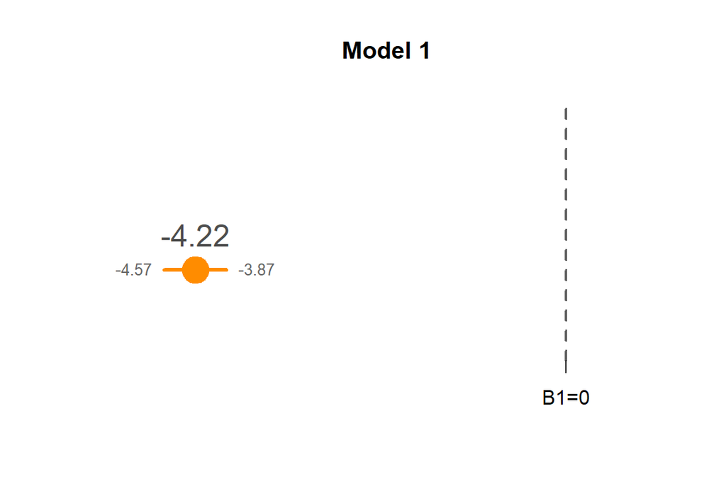

### Q (3)

Calculate the 95% confidence interval around the class size coefficient in Model 2. Is it significant at this level? How do you know?

$-3.97 < b_1 < -3.85$

**The slope is statistically significant because it does NOT contain the null of b1=0.**

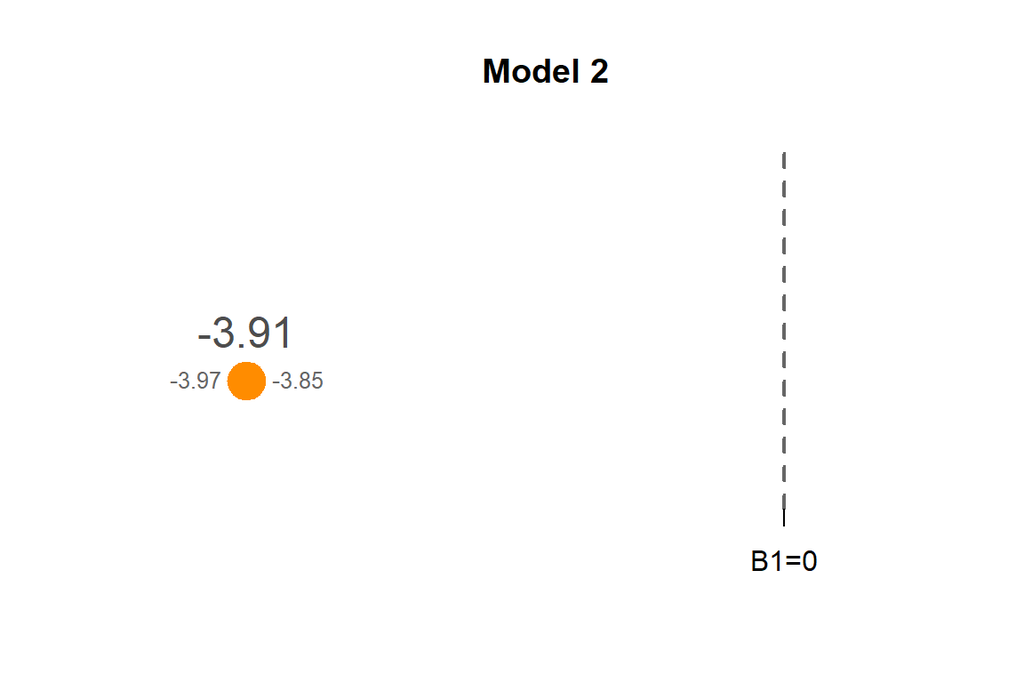

### Q (4)

Calculate the 95% confidence interval around the class size coefficient in Model 4. Is it significant at this level? How do you know?

$-5.86 < b_1 < 0.52$

**The slope is NOT statistically significant because it DOES contain the null of b1=0, meaning we can no longer say for certain if the impact is positive or negative.**

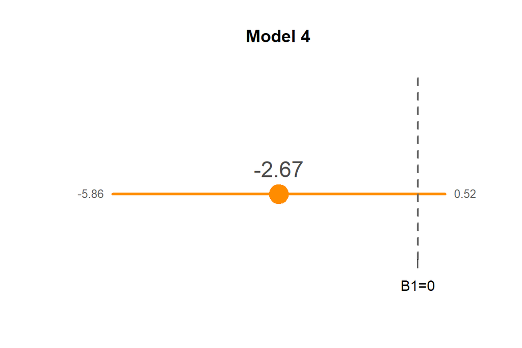

### Q (5)

Draw the three confidence intervals to see how they change (you can do this in any drawing tool, with R, in MS Word or PowerPoint, or by hand).

**See above**

```r
b1 <- -2.67
se <- 1.63
upper.ci <- b1 + 1.96*se
lower.ci <- b1 - 1.96*se
plot( c(lower.ci,upper.ci), c(1,1),
      xlim=c(lower.ci,1), ylim=c(0,3),
      xlab="", ylab="", axes=F, bty="n",
      type="l", lwd=3, col="darkorange",
      main="Model 4" )
points( b1, 1, col="darkorange", pch=19, cex=3 )
text( b1, 1, b1, pos=3, col="gray30", cex=1.5, offset=1 )
abline( v=0, lty=2, lwd=2, col="gray40" )
axis( side=1, at=0, labels="B1=0" )
```

### Q (6)

The covariance of class size and test scores is -418, and the variance of class size is 99. Can you calculate the slope of class size in Model 4 with the formula cov(x,y)/var(x)? Why or why not?

**The formula cov(x,y) / var(x) here generates the slope from Model-01, the model that contains only the variables X and Y from this formula (class size and test scores in the example here).**

**We CANNOT use this same formula for Model 4 because it does not account for the additional control variables.**

What I wante you to note is that once you start adding control variables (1) the slope of classroom size likely changes, and (2) consequently we need a more complicated formula to calculate the slope when controls are involved.**

We will not calculate slopes from a multiple regression model by hand (thus I’m not sharing the formula here - it is pretty complicated). **The basic formula cov(x,y)/var(x) is meant to provide intuition about the models**, but it will not give you a precise answer any time control variables are included in the model.

Looking ahead, pay attention to the specific ways that control variables impact models.

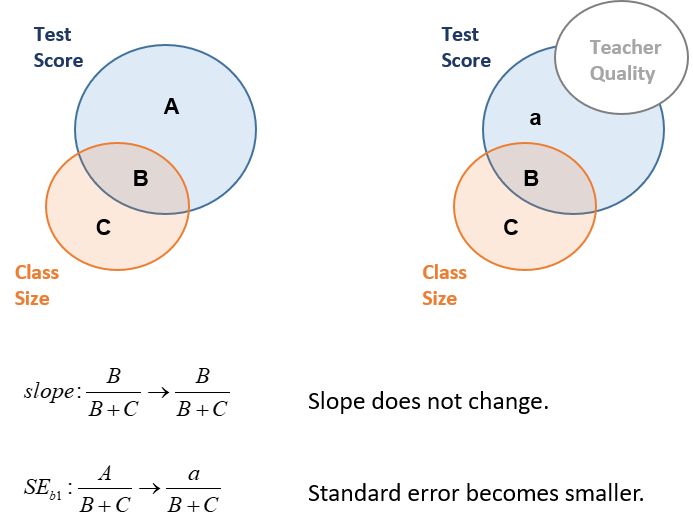

The correlation between independent variables is an important consideration in multivariate models.

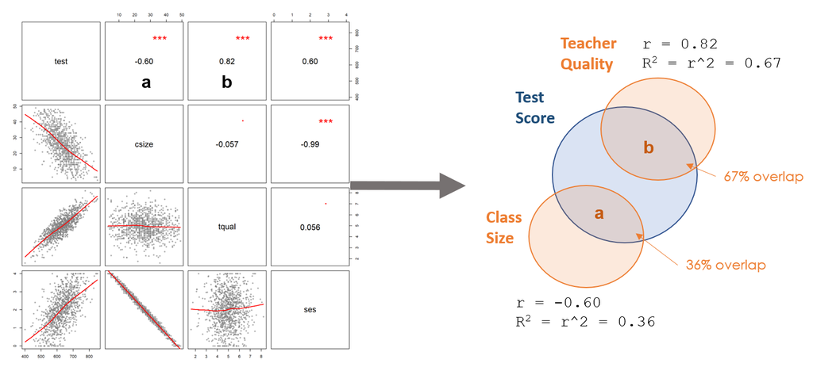

# Notes on Reading Regression Tables

It is common to compare regression models with different specification (including or excluding variables) to ensure we have the best fit. To present multiple models compactly we display each model as a column in the table. You can read them as follows:

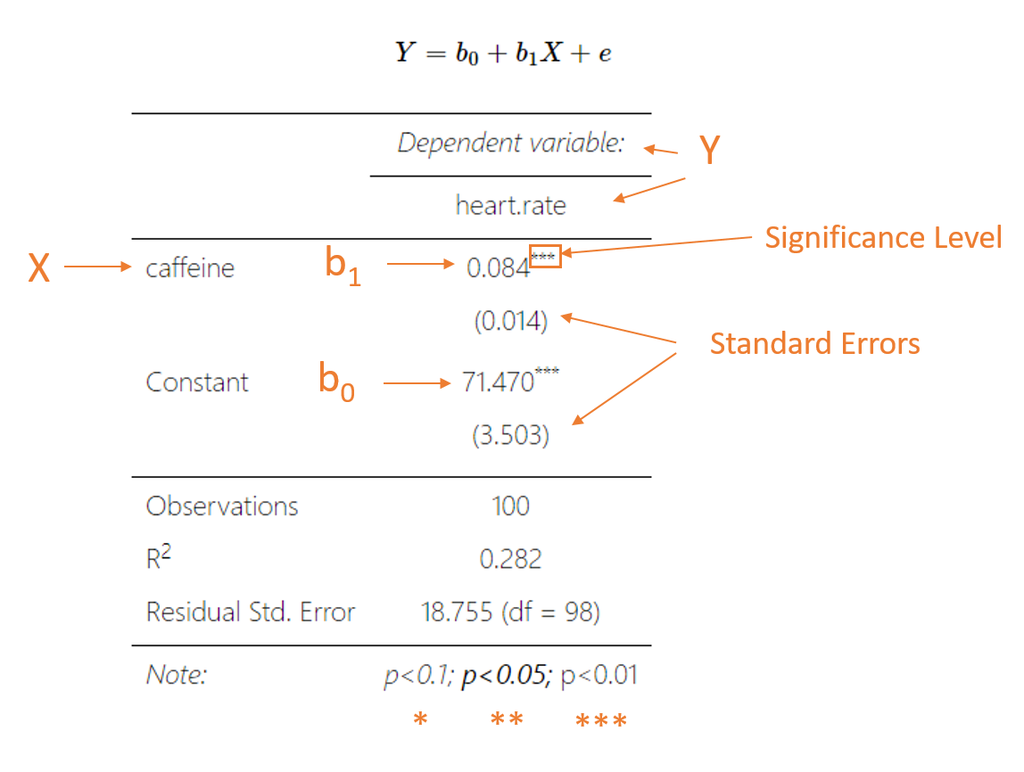

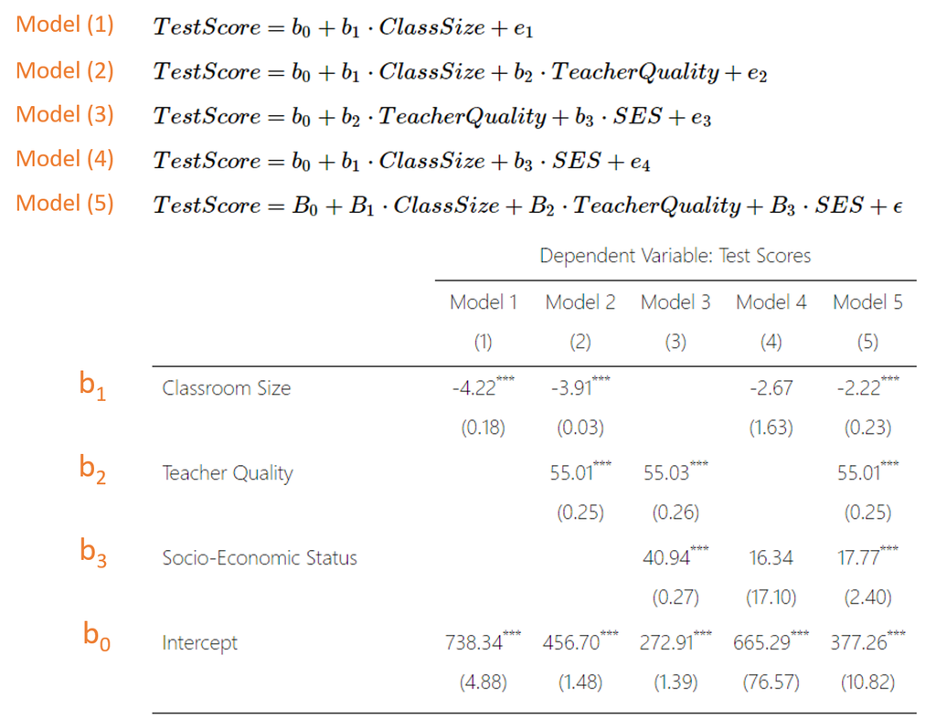